# HiTMaP

– An R package of High-resolution Informatics Toolbox for Maldi-imaging Proteomics

## 0.1 Package installation

This is an tutorial for use of HiTMaP (An R package of High-resolution Informatics Toolbox for Maldi-imaging Proteomics). To access the software use the installation codes as below:

```r
#install the git package
install.packages("devtools")
Sys.setenv(R_REMOTES_NO_ERRORS_FROM_WARNINGS=T)
library(devtools)
install_github("guoguodigit/HiTMaP",auth_token ="a124a067ed1c84f8fd577c972845573922f1bb0f",force=T)
#Update all dependencies
1
library(HiTMaP)
```

## 0.2 Proteomics identification on Maldi imaging data file

Now the HiTMaP is upon running. You could build the candidate list of your target proteome and perform image identification by using the function as below:

```r
#creat candidate list
library(HiTMaP)
#set project folder that contains imzML, .ibd and fasta files
wd=paste0(file.path(path.package(package="HiTMaP")),"/data/")
#set a series of imzML files to be processed
datafile=c("Bovin_lens")


imaging_identification(
#==============Choose the imzml raw data file(s) to process  make sure the fasta file in the same folder
               datafile=paste0(wd,datafile),
               threshold=0.005,
               ppm=5,
#==============specify the digestion enzyme specificity
               Digestion_site="([KR](?=[^P]))|((?<=W)K(?=P))|((?<=M)R(?=P))",
#==============specify the range of missed Cleavages
               missedCleavages=0:1,
#==============Set the target fasta file
               Fastadatabase="uniprot-bovin.fasta",
#==============Set the possible adducts and fixed modifications
               adducts=c("M+H"),
               Modifications=list(fixed=NULL),
#==============The decoy mode: could be one of the "adducts", "elements" or "isotope"
               Decoy_mode = "isotope",
               use_previous_candidates=F,
               output_candidatelist=T,
#==============Set the parameters for image segmentation
               spectra_segments_per_file=5,
               spatialKMeans=TRUE,
               Smooth_range=1,
               Virtual_segmentation=FALSE,
               Virtual_segmentation_rankfile=NULL,
#==============Set the Score method for hi-resolution isotopic pattern matching
               score_method="SQRTP",
#==============Summarise the protein and peptide features across the project the result can be found at the summary folder
               Protein_feature_summary=TRUE,
               Peptide_feature_summary=TRUE,
               Region_feature_summary=TRUE,
#==============The parameters for Cluster imaging. Specify the annotations of interest, the program will perform a case-insensitive search on the result file, extract the protein(s) of interest and plot them in the cluster imaging mode
               plot_cluster_image_grid=FALSE,
               ClusterID_colname="Protein",
               componentID_colname="Peptide",
               Protein_desc_of_interest=c("Crystallin","Actin"),
               Rotate_IMG=NULL,
               )
```

## 0.3 Project folder and result structure

In the above function, You have performed proteomics analysis of the sample data file. It is a tryptic Bovin lens MALDI-imaging file which is acquired on an FT-ICR MS. The function will take the selected data files’ root directory as the project folder. In this example, the project folder will be:

```r
library(HiTMaP)
wd=paste0("Y:\\MALDI\\George\\bltryp\\")
#set a series of imzML files to be processed
datafile=c("bl_tryp")
wd
```

```
## [1] "Y:\\MALDI\\George\\bltryp\\"
```

After the whole identification process, we will get two types of sub-folders in the project folder:

```r
list.dirs(wd, recursive=FALSE)
```

```
## [1] "Y:\\MALDI\\George\\bltryp\\/bl_tryp ID"
## [2] "Y:\\MALDI\\George\\bltryp\\/bl_tryp ID peptide_ID_filter2"
## [3] "Y:\\MALDI\\George\\bltryp\\/Summary folder"
```

## 0.4 Identification result visulasation and interpretation

Now we could visualize the result by the following functions:

To check the segmentation result over the sample, you need got to each data file ID folder and find the “spatialKMeans_image_plot.png” (if you are using the spatial K-means method for segmentation.)

```r
library(magick)
```

```
## # A tibble: 1 x 7
##   format width height colorspace matte filesize density
##   <chr>  <int>  <int> <chr>      <lgl>    <int> <chr>
## 1 PNG     1024    720 sRGB       FALSE    10651 72x72
```

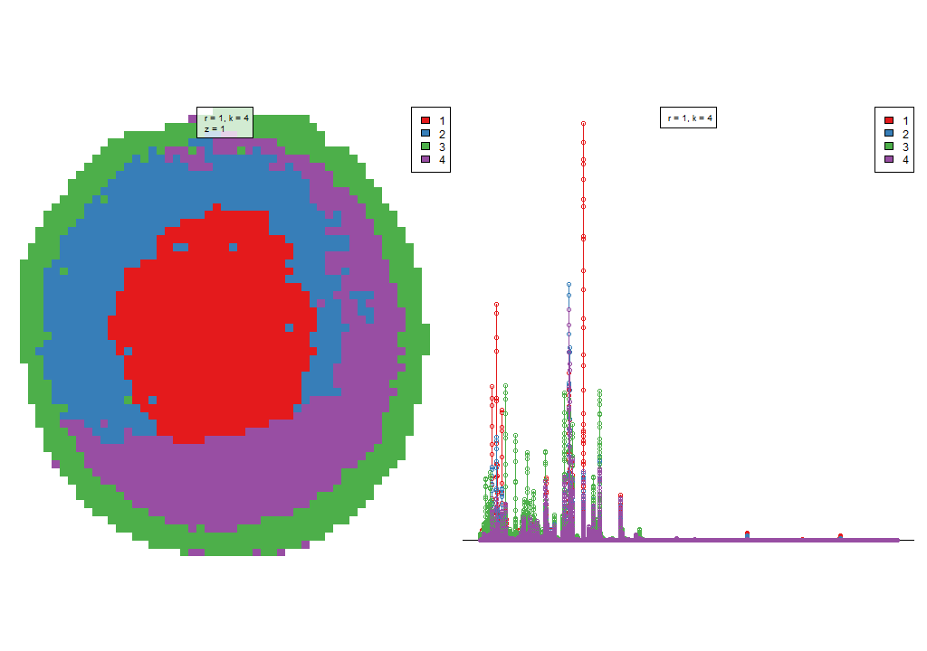

```r
p<-image_read(paste0(wd,datafile," ID/spatialKMeans_image_plot.png"))
print(p)
```

The identification will take place on the **mean spectra** of each region. To check the peptide mass fingerprint (PMF) matching quality, you could locate the PMF spectrum matching plot of each individual region.

```
## # A tibble: 1 x 7
##   format width height colorspace matte filesize density
##   <chr>  <int>  <int> <chr>      <lgl>    <int> <chr>
## 1 PNG     1980   1080 sRGB       FALSE    19047 72x72
```

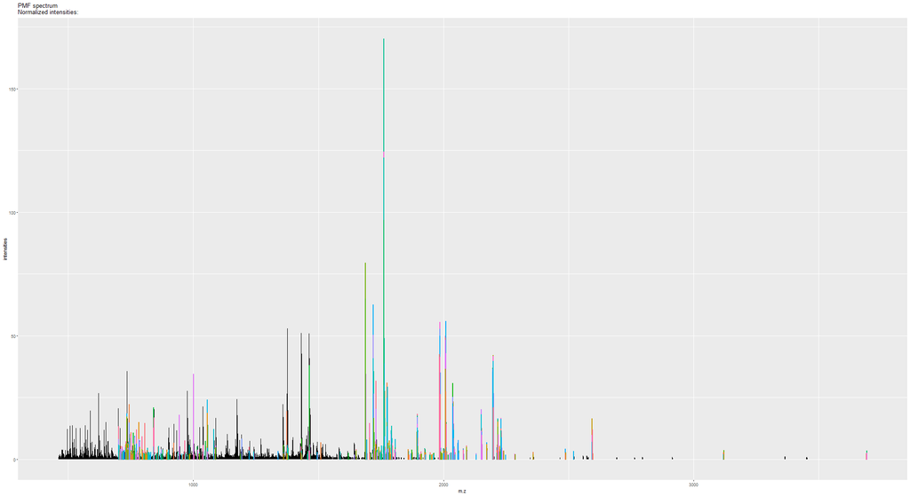

```r
library(magick)
p_pmf<-image_read(paste0(wd,datafile," ID/",datafile," 3PMF spectrum match.png"))
print(p_pmf)
```

list of Peptides and proteins of each region has also been created so that you may check each individual region’s result.

```r
peptide_pmf_result<-read.csv(paste0(wd,datafile," ID/Peptide_segment_PMF_RESULT_3.csv"))
head(peptide_pmf_result)
```

```
## # A tibble: 6 x 15
##   Protein    mz Peptide adduct formula isdecoy pepmz charge Intensity
##     <int> <dbl> <fct>   <fct>  <fct>     <int> <dbl>  <int>     <dbl>
## 1     101 2011. FSLTYL~ M+H    C91H14~       0 2010.      1    10.8
## 2     101 1694. KFSLTY~ M+H    C78H12~       0 1693.      1     0.661
## 3     101  843. LLWVRR  M+H    C40H68~       0  842.      1     8.37
## 4     101 1896. HDEDID~ M+H    C77H11~       0 1895.      1     0.861
## 5     115  741. QDIPLR  M+H    C32H57~       0  740.      1     2.31
## 6     115 2094. AAGIAS~ M+H    C93H13~       0 2093.      1     3.02
## # ... with 6 more variables: moleculeNames <fct>, Region <int>,
## #   Score <dbl>, mz_align <dbl>, Rank <int>, desc <fct>
```

```r
protein_pmf_result<-read.csv(paste0(wd,datafile," ID/Protein_segment_PMF_RESULT_3.csv"))
head(protein_pmf_result)
```

```
## # A tibble: 6 x 9
##   Protein Proscore isdecoy Intensity Score peptide_count Protein_coverage
##     <int>    <dbl>   <int>     <dbl> <dbl>         <int>            <dbl>
## 1     101    0.605       0      5.17  1.52             4            0.320
## 2   10118    1.05        0      9.75  2.61             6            0.234
## 3    1014    0.631       0      3.56  1.21            14            0.542
## 4   10188    0.857       0      5.65  2.15             9            0.304
## 5   10240    0.626       0     13.2   1.86             5            0.172
## 6   10461    1.55        0     12.0   1.38             9            0.598
## # ... with 2 more variables: Intensity_norm <dbl>, desc <fct>
```

## 0.5 Scoring system for protein and peptide

**Score** in peptide result table shows the isotopic pattern matching score of the peptide. In Protein result table, it shows the intensity weighted peptide spectrum matching score.

$Score=\log(Observed\_Peak/Theoritical\_peak)-\log(\sqrt{\frac{\sum_{x = 1}^{n} (Theoritical\_intensity_x-Observed\_intensity_x)^2}{\sum_{x = 1}^{n} (Theoritical\_intensity_x)^2(Observed\_intensity_x)^2}}$

**Proscore** in the protein result table shows the overall estimation of the protein identification Accuracy

$Proscore=\frac{\sum_{x = 1}^{n}(Score_x*log(Intensity_x))}{mean(log(Intensity))}*Protein\_coverage*Normalized\_intensity$

A *Peptide_region_file.csv* has also been created to summarise all the IDs in this data file:

```r
Identification_summary_table<-read.csv(paste0(wd,datafile," ID/Peptide_region_file.csv"))
head(Identification_summary_table)
```

```
## # A tibble: 6 x 15
##   Protein    mz Peptide adduct formula isdecoy pepmz charge Intensity
##     <int> <dbl> <fct>   <fct>  <fct>     <int> <dbl>  <int>     <dbl>
## 1     101 2011. FSLTYL~ M+H    C91H14~       0 2010.      1    10.8
## 2     101 1694. KFSLTY~ M+H    C78H12~       0 1693.      1     0.661
## 3     101  843. LLWVRR  M+H    C40H68~       0  842.      1     8.37
## 4     101 1896. HDEDID~ M+H    C77H11~       0 1895.      1     0.861
## 5     115  741. QDIPLR  M+H    C32H57~       0  740.      1     2.31
## 6     115 2094. AAGIAS~ M+H    C93H13~       0 2093.      1     3.02
## # ... with 6 more variables: moleculeNames <fct>, Region <int>,
## #   Score <dbl>, mz_align <dbl>, Rank <int>, desc <fct>
```

The details of protein/peptide identification process has been save to the folder named by the segmentation:

```r
list.dirs(paste0(wd,datafile," ID/"), recursive=FALSE)
```

```
## [1] "Y:\\MALDI\\George\\bltryp\\bl_tryp ID//1"
## [2] "Y:\\MALDI\\George\\bltryp\\bl_tryp ID//2"
## [3] "Y:\\MALDI\\George\\bltryp\\bl_tryp ID//3"
## [4] "Y:\\MALDI\\George\\bltryp\\bl_tryp ID//4"
```

In the identification details folder, you will find a series of FDR file and plots to demonstrate the FDR model and score cutoff threshold:

```r
dir(paste0(wd,datafile," ID/1/"), recursive=T)
```

```
##  [1] "FDR.CSV"
##  [2] "FDR.png"
##  [3] "Matching_Score_vs_mz_target-decoy.png"
##  [4] "Peptide_1st_ID.csv"
##  [5] "Peptide_1st_ID_score_rank_SQRTP.csv"
##  [6] "Peptide_2nd_ID_score_rankSQRTP_Rank_above_3.csv"
##  [7] "Peptide_Score_histogram_target-decoy.png"
##  [8] "PROTEIN_FDR.CSV"
##  [9] "protein_FDR.png"
## [10] "Protein_ID_score_rank_SQRTP.csv"
## [11] "PROTEIN_Score_histogram.png"
## [12] "Spectrum.csv"
## [13] "unique_peptide_ranking_vs_mz_feature.png"
```

In this folder, you will find the FDR plots for protein and peptide. The software will take the proscore and its FDR model to trim the final identification result. The *unique_peptide_ranking_vs_mz_feature.png* is a plot that could tell you the number of peptide candidates have been matched to the mz features in the first round run.You can also access the peptide spectrum match (first MS dimension) data via the “/ppm” subfolder.

```
## # A tibble: 1 x 7
##   format width height colorspace matte filesize density
##   <chr>  <int>  <int> <chr>      <lgl>    <int> <chr>
## 1 PNG      960    480 sRGB       FALSE    16094 72x72
```

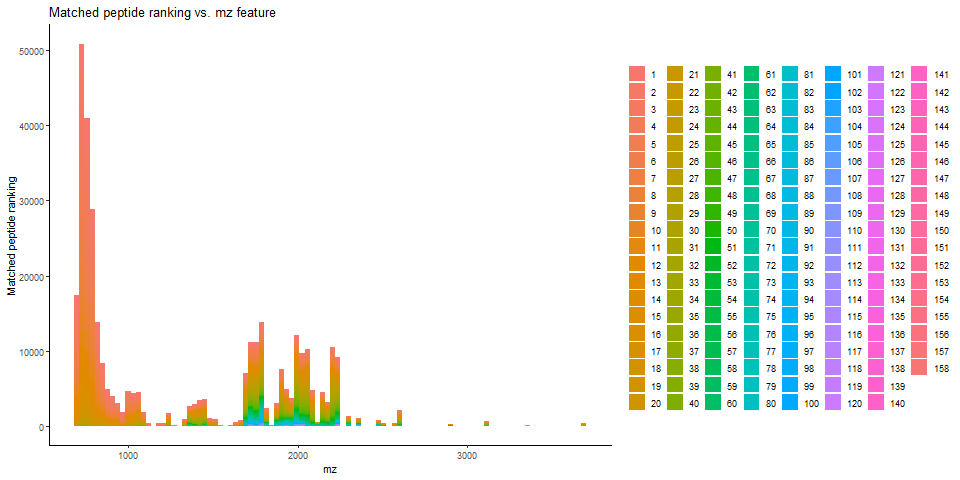

```r
library(magick)
p_peptide_vs_mz_feature<-image_read(paste0(wd,datafile," ID/3/unique_peptide_ranking_vs_mz_feature.png"))
print(p_peptide_vs_mz_feature)
```

```
## # A tibble: 1 x 7
##   format width height colorspace matte filesize density
##   <chr>  <int>  <int> <chr>      <lgl>    <int> <chr>
## 1 PNG     1920    480 sRGB       FALSE        0 72x72
```

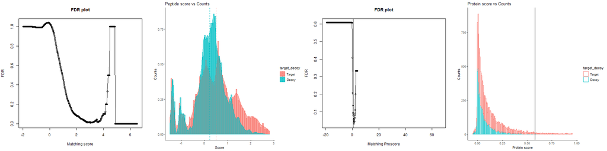

```r
p_FDR_peptide<-image_read(paste0(wd,datafile," ID/3/FDR.png"))
p_FDR_protein<-image_read(paste0(wd,datafile," ID/3/protein_FDR.png"))
p_FDR_peptide_his<-image_read(paste0(wd,datafile," ID/3/Peptide_Score_histogram_target-decoy.png"))
p_FDR_protein_his<-image_read(paste0(wd,datafile," ID/3/PROTEIN_Score_histogram.png"))
p_combined<-image_append(c(p_FDR_peptide,p_FDR_peptide_his,p_FDR_protein,p_FDR_protein_his))
print(p_combined)
```

you will also find a *Matching_Score_vs_mz* plots for further investigation on peptide matching quality.

```
## # A tibble: 1 x 7
##   format width height colorspace matte filesize density
##   <chr>  <int>  <int> <chr>      <lgl>    <int> <chr>
## 1 PNG      480    480 sRGB       FALSE    64461 72x72
```

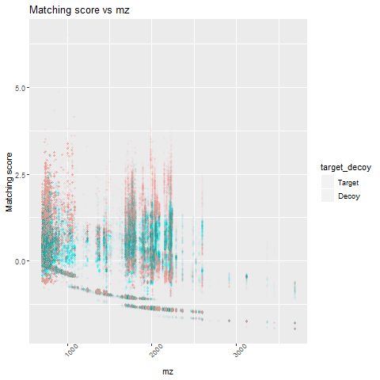

```r
library(magick)
p_Matching_Score_vs_mz<-image_read(paste0(wd,datafile," ID/3/Matching_Score_vs_mz_target-decoy.png"))
print(p_Matching_Score_vs_mz)
```

## 0.6 Identification summary and cluster imaging

```r
wd_sum=paste(file.path(path.package(package="HiTMaP")),"/data/Summary folder", sep="")
dir(wd_sum)
```

```
## [1] "candidatelist.csv"    "cluster Ion images"   "Peptide_Summary.csv"
## [4] "protein_index.csv"    "Protein_Summary.csv"  "Protein_Summary.xlsx"
```

“candidatelist.csv” and “protein_index.csv” contains the candidates used for this project. They are output after the candidate processing while *output_candidatelist* set as TRUE, and can be used repeatedly while *use_previous_candidates* set as TRUE.

“Peptide_Summary.csv” and “Protein_Summary.csv” contains the table of the project identification summary. You could set the *plot_cluster_image_grid* as TRUE to enable the cluster imaging function. Please be noted that you could indicate *Rotate_IMG* with a CSV file path that indicates the rotation degree of image files.

**Note**: 90$^\circ$, 180$^\circ$ and 270$^\circ$ are recommended for image rotation. You may find an example CSV file in the library/HiTMaP/data folder.

Now you could visualized the interest proteins and their associated peptides’ distribution via cluster imaging function.

```
## # A tibble: 1 x 7
##   format width height colorspace matte filesize density
##   <chr>  <int>  <int> <chr>      <lgl>    <int> <chr>
## 1 PNG     1980    599 sRGB       TRUE    579137 118x118
```

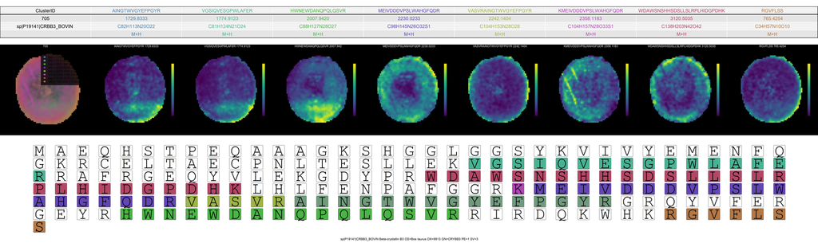

```r
p_cluster1<-image_read(paste0(wd,"/Summary folder/cluster Ion images/705_cluster_imaging.png"))
print(p_cluster1)
```

```
## # A tibble: 1 x 7
##   format width height colorspace matte filesize density
##   <chr>  <int>  <int> <chr>      <lgl>    <int> <chr>
## 1 PNG     1980   1150 sRGB       TRUE    660577 118x118
```

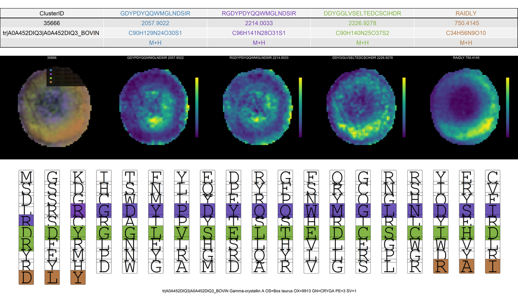

```r
p_cluster2<-image_read(paste0(wd,"/Summary folder/cluster Ion images/35666_cluster_imaging.png"))
print(p_cluster2)
```

```
## # A tibble: 1 x 7
##   format width height colorspace matte filesize density
##   <chr>  <int>  <int> <chr>      <lgl>    <int> <chr>
## 1 PNG     1980    631 sRGB       TRUE    582868 118x118
```

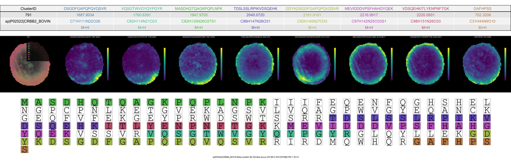

```r
p_cluster3<-image_read(paste0(wd,"/Summary folder/cluster Ion images/791_cluster_imaging.png"))
print(p_cluster3)
```

End of the tutorial, Enjoy~